# Multiple_Co-Inertia_Analysis

Eric D. Crandall

December 8, 2015

I’m going to start building a script to perform Multiple Co-Inertia Analysis as described in [Laloe et al 2007](http://gse-journal.org/articles/gse/abs/2007/05/g06098/g06098.html). There is an example given in the [adegenet documentation](https://cran.r-project.org/web/packages/adegenet/adegenet.pdf) for the dataset *microbov*.

## Importing the data

First, build the ipdb object using code from DIPnet_Stats_Script.R

With some futzing I was able to make the adegenet example work on the microbov dataset - main difference is that `nsamp` needs to come from `kx$blo` because the allelic frequency table is now just a matrix, not a list of objects.

## Making the Genind object

So it seems like the easiest thing wil be to make a genpop object where each ‘locus’ is a species, the alleles are haplotypes and the populations are populations. To do this I will use `genpop()` and I need to give it a table with species/gsls as columns and populations as rows. Start with one gsl:

```
##
##  Converting data from a genind to a genpop object...
##
## ...done.
```

```
## /// GENPOP OBJECT /////////
##
##  // 7 populations; 1 locus; 521 alleles; size: 77 Kb
##
##  // Basic content
##    @tab:  7 x 521 matrix of allele counts
##    @loc.n.all: number of alleles per locus (range: 521-521)
##    @loc.fac: locus factor for the 521 columns of @tab
##    @all.names: list of allele names for each locus
##    @ploidy: ploidy of each individual  (range: 2-2)
##    @type:  codom
##    @call: genind2genpop(x = spseqs.genind)
##
##  // Optional content
##    - empty -
```

Extending this to multiple gsls means we have to loop through them, converting them from the ipdb database format through seqinr, DNAbin, genind and genpop format. We rename the alleles of each gsl so its clear that they came from that species, then we can cbind them into a single table that can be turned into a genind object that will see the gsls as loci:

[output not shown]

```
## /// GENPOP OBJECT /////////
##
##  // 4 populations; 11 loci; 2,587 alleles; size: 404.2 Kb
##
##  // Basic content
##    @tab:  4 x 2587 matrix of allele counts
##    @loc.n.all: number of alleles per locus (range: 64-774)
##    @loc.fac: locus factor for the 2587 columns of @tab
##    @all.names: list of allele names for each locus
##    @ploidy: ploidy of each individual  (range: 2-2)
##    @type:  codom
##    @call: .local(x = x, i = i, j = j, drop = drop)
##
##  // Optional content
##    - empty -
```

## Converting to ktab format

Now I just follow the example in the [adegenet documentation](https://cran.r-project.org/web/packages/adegenet/adegenet.pdf) - Page 103 of the current version (search for microbov)

```
##
##  Finding allelic frequencies from a genpop object...
##
## ...done.
```

```
##                               Length Class      Mode
## Acanthaster_planciPac_CR       774   data.frame list
## Nerita_albicilla_CO1           347   data.frame list
## Holothuria_atra_CO1             64   data.frame list
## Linckia_laevigata_CO1          190   data.frame list
## Tridacna_maxima_CO1            197   data.frame list
## Tridacna_crocea_CO1            194   data.frame list
## Tridacna_squamosa_CO1           64   data.frame list
## Caesio_cuning_CR               207   data.frame list
## Haptosquilla_glyptocercus_CO1  202   data.frame list
## Haptosquilla_pulchella_CO1     186   data.frame list
## Gonodactylellus_viridis_CO1    162   data.frame list
## lw                               4   -none-     numeric
## cw                            2587   -none-     numeric
## blo                             11   -none-     numeric
## TL                               2   data.frame list
## TC                               2   data.frame list
## T4                               2   data.frame list
## call                             3   -none-     call
```

## perform %PCA on each genus-species-locus (gsl) combination

These PCAs are all on different axes from one another. The numbers correspond to haplotypes.

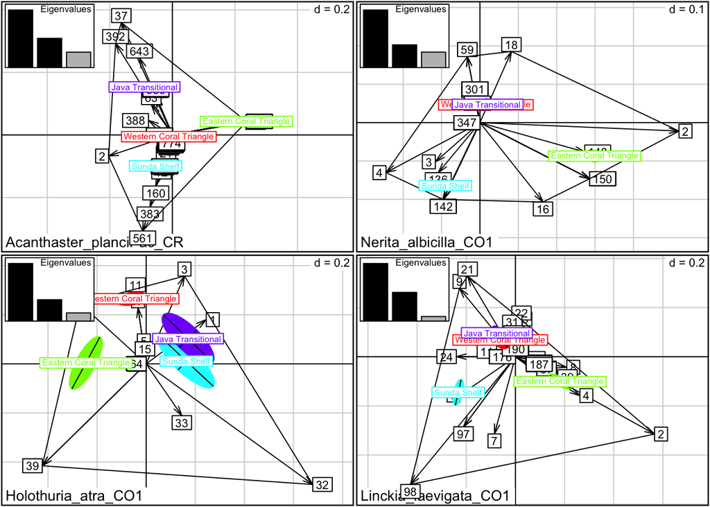

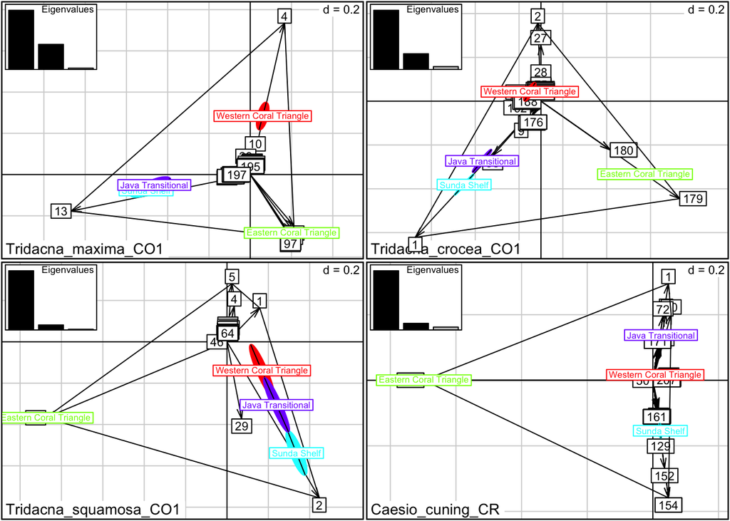

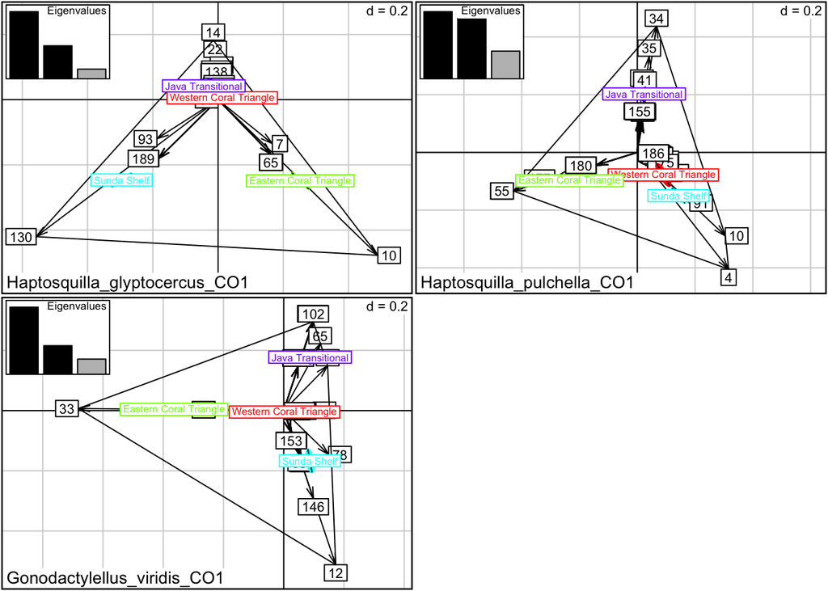

## Perform Multiple co-inertia analysis

This is the “reference typology” meaning the consensus PCA of all gsls, showing the relationship of co-sampled populations.

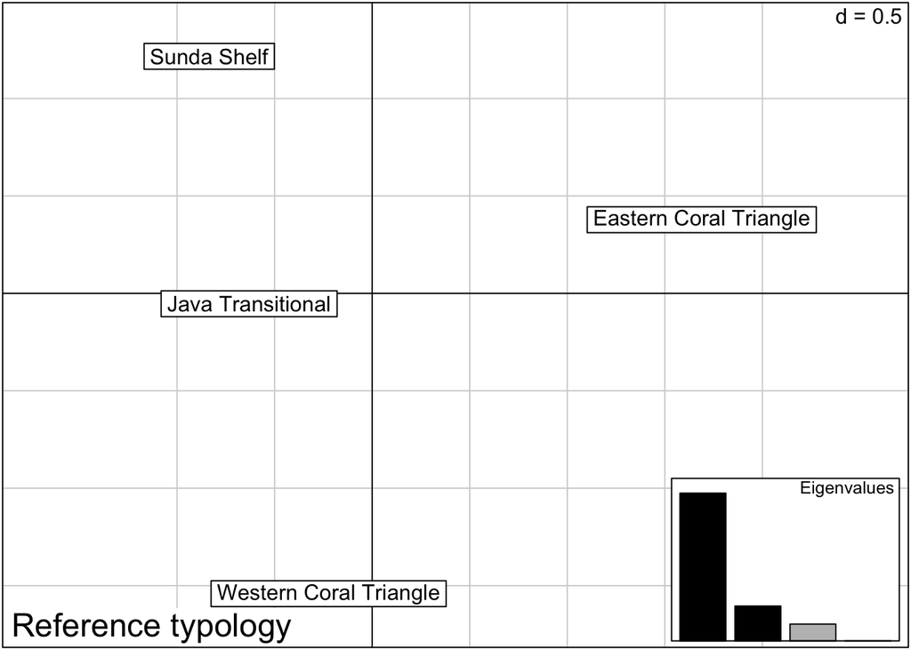

## Coordinated %PCA

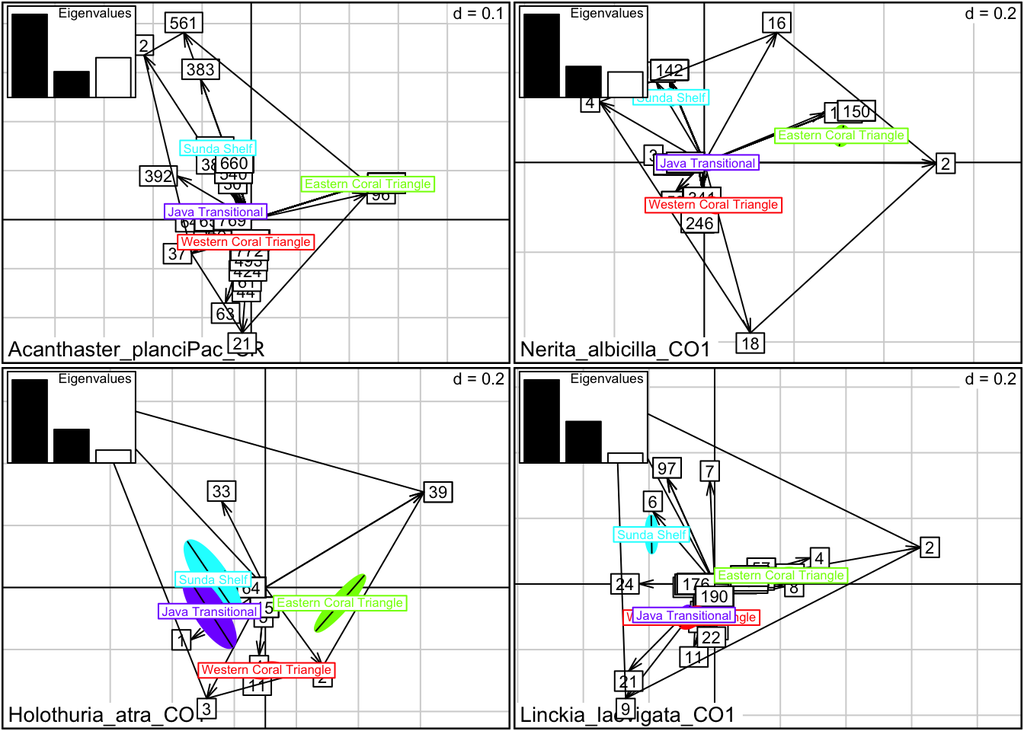

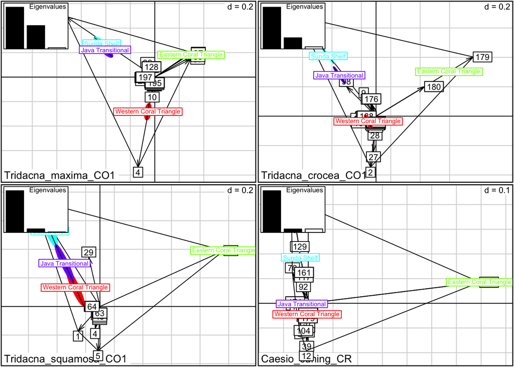

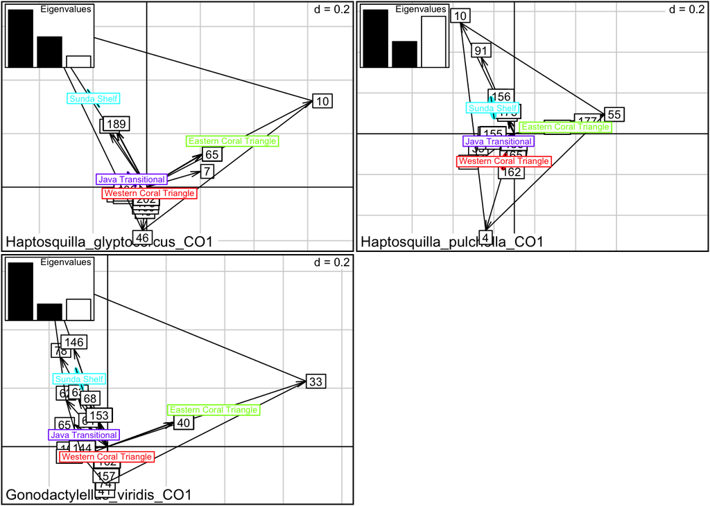

## Still to do

- Cohesion plots
- Try different regionalizations, gsl sets.
- Re-read [Laloe et al 2007](http://gse-journal.org/articles/gse/abs/2007/05/g06098/g06098.html)